# wrangle_report

```python
import pandas as pd
import seaborn as sns
import matplotlib.pyplot as plt
%matplotlib inline
df_clean = pd.read_csv('WeRateDogs_clean.csv')
```

As I mentioned in my Notebook, I asked the following questions of the data:

- Is there any shift over time in number of tweets — is WeRateDogs getting more or less popular in this time?
- What are the most common breeds? How are they rated — do certain breeds fare better in the rating system?
- Do tweets with higher ratings get retweeted or marked as favorites more often?
- What are the most common dog names? Are certain names associated with higher ratings?

##### An executive summary of sorts

There were a few insights I had after analyzing the data.

- WeRateDogs experienced and initial surge in popularity as measured by retweets, followed by a decrease and then a gradual but discernable increase in popularity for the period covered (2015-2017).
- The most common breeds on WeRateDogs are what we would expect based on the Americans' overall pet preferences (I am assuming that most people accessing the account are American or North American because of the language used and pet culture, but this could be worth examining), i.e. golden retrievers and labradors. These breeds also received high ratings, but less common breeds like Bouvier des flandres, a Saluki, and Briads figure more prominently. While this is mostly due to the small number of instances of these breeds appearing, it also seems likely that unique breeds attact more attention and allow more creativity for unusal observations in the tweets.
- Tweets with higher ratings were clearly much more likely to be retweeted than tweets with lower ratings (except for very low ratings)

[figure not shown]

The first preliminary question I had was: what was the most favorite and most retweeted tweet? The most favorited was of a dog learning to stand in water, while the most retweeted was this one of a dog at a women's march in Toronto in 2017:

#### Popularity of WeRateDogs from 2015-17

As we can see, by the metric of number of unqiue tweets, it appears that WeRateDogs experienced a spike in popularity just after it was created in November 2015. However, by the metric of number of retweets, although there is a spike at the beginning, the number of retweets is more level. Fitting a quick linear regression shows it is quite likely the number of retweets is increasing slightly with time.

[figure not shown]

#### Popularity of breeds on on WeRateDogs

While the most common dogs in the American pet inventory (golden retrievers and labradors in particular — lists of the most common breeds are available [here](https://www.akc.org/most-popular-breeds/)) are well represented in WeRateDog's tweets, the breeds that receive the highest ratings are more exotic. Here are the top ten highest ranked, and the visualizalion below shows the top 30.

[figure not shown]

However the most highly rated dogs on the account are from less usual breeds:

```python
rank_by_breed = df_clean.groupby(['breed'])['rating_numerator'].mean().sort_values(ascending=False).to_frame()
rank_by_breed[:10]
```

| breed | rating_numerator |
| --- | --- |
| Bouvier_des_flandres | 13.000000 |
| Saluki | 12.500000 |
| Briard | 12.333333 |
| Tibetan_mastiff | 12.250000 |
| Border_terrier | 12.142857 |
| Standard_schnauzer | 12.000000 |
| Silky_terrier | 12.000000 |
| Irish_setter | 11.750000 |
| Gordon_setter | 11.750000 |
| Samoyed | 11.690476 |

#### Higher-rated Tweets get retweeted more often.

```python
by_rating = df_clean.groupby('rating_numerator', as_index=False)['retweets'].sum()
by_rating['tweet_id'] = df_clean.groupby('rating_numerator', as_index=False)['tweet_id'].count()['tweet_id']
by_rating['proportion'] = by_rating.retweets / by_rating.tweet_id
by_rating
```

|  | rating_numerator | retweets | tweet_id | proportion |
| --- | --- | --- | --- | --- |
| 0 | 0.00 | 3443 | 1 | 3443.000000 |
| 1 | 2.00 | 3007 | 2 | 1503.500000 |
| 2 | 3.00 | 5432 | 5 | 1086.400000 |
| 3 | 4.00 | 7185 | 6 | 1197.500000 |
| 4 | 5.00 | 21269 | 14 | 1519.214286 |
| 5 | 6.00 | 18856 | 16 | 1178.500000 |
| 6 | 7.00 | 27267 | 31 | 879.580645 |
| 7 | 8.00 | 53573 | 68 | 787.838235 |
| 8 | 9.00 | 112224 | 132 | 850.181818 |
| 9 | 9.75 | 7069 | 1 | 7069.000000 |
| 10 | 10.00 | 527477 | 360 | 1465.213889 |
| 11 | 11.00 | 767151 | 356 | 2154.918539 |
| 12 | 11.26 | 542 | 1 | 542.000000 |
| 13 | 11.27 | 1885 | 1 | 1885.000000 |
| 14 | 12.00 | 1330753 | 423 | 3145.988180 |
| 15 | 13.00 | 1615656 | 229 | 7055.266376 |
| 16 | 14.00 | 203485 | 23 | 8847.173913 |

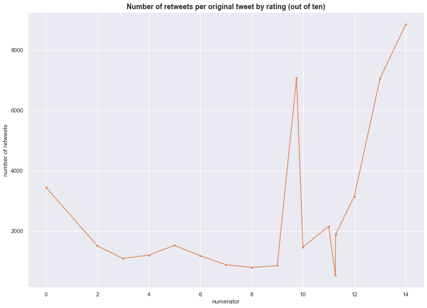

```python
sns.set()
plt.subplots(figsize=(14, 10))
plt.plot(by_rating['rating_numerator'], by_rating['proportion'], 'C1.-')
plt.title('Number of retweets per original tweet by rating (out of ten)',  fontsize=14, fontweight='bold')
plt.xlabel('numerator')
plt.ylabel('number of retweets')
```